# Sowing Dates for Crop suitability models

## Maize

FEWSNET > CCD

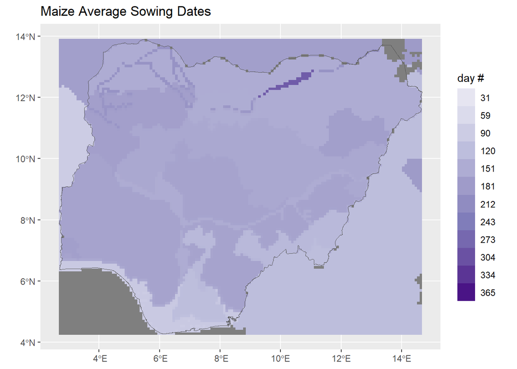

```r
rast_maize_lz_rsmp <- resample(rast_maize_lz, rast_maize_ccd )
rast_maize_sacra <- resample(rast_sow1_sacra, rast_maize_ccd )

rast_maize <- ifel(
  !is.na(rast_maize_lz_rsmp),  rast_maize_lz_rsmp, rast_maize_ccd$plant)


ggplot() +
  geom_spatraster(data = rast_maize) +
    scale_fill_distiller(
    type = "seq",
    palette = "Purples",
    direction = 1,
    limits = c(1, 365),
    breaks = c(31,59,90,120,151,181,212,243,273,304,334,365),
    labels = label_comma(),
    guide = "legend"
  ) +
  geom_spatvector(data = vect_ng_geo, fill = NA) +
  labs(title = "Maize Average Sowing Dates", fill = "day #") +
  theme(
    plot.title = element_markdown(),
    axis.title = element_blank()
  )
```

```r
# writeRaster(rast_maize, "E:/repos/IRM_shiny/data/spatial_data/onset_maize_generic_nigeria.tif", overwrite=TRUE)
```

The sowing dates above gave good results for most areas. But the pattern in the north west of Nigeria, looks odd because of the riverine livelihood zone.

Therefore, we tried a number of static sowing dates to test their impact on climatic suitability.

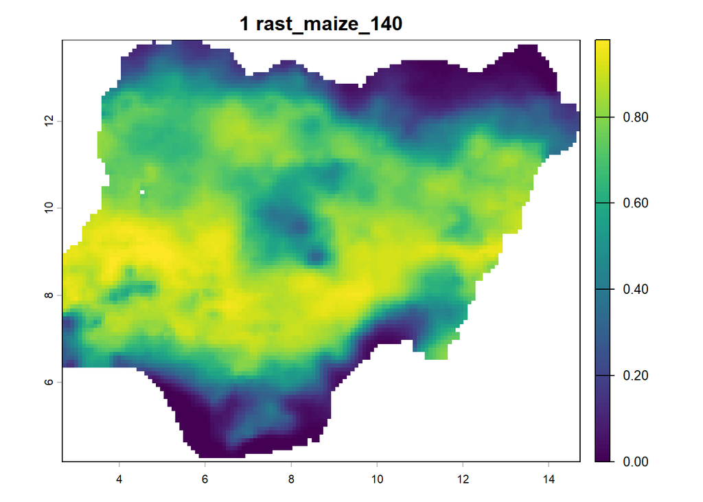

```r
wkt_geo <-  paste0( "
  GEOGCRS[\"WGS 84 (with axis order normalized for visualization)\",
          ENSEMBLE[\"World Geodetic System 1984 ensemble\",
                   MEMBER[\"World Geodetic System 1984 (Transit)\",
                          ID[\"EPSG\",1166]],
                   MEMBER[\"World Geodetic System 1984 (G730)\",
                          ID[\"EPSG\",1152]],
                   MEMBER[\"World Geodetic System 1984 (G873)\",
                          ID[\"EPSG\",1153]],
                   MEMBER[\"World Geodetic System 1984 (G1150)\",
                          ID[\"EPSG\",1154]],
                   MEMBER[\"World Geodetic System 1984 (G1674)\",
                          ID[\"EPSG\",1155]],
                   MEMBER[\"World Geodetic System 1984 (G1762)\",
                          ID[\"EPSG\",1156]],
                   MEMBER[\"World Geodetic System 1984 (G2139)\",
                          ID[\"EPSG\",1309]],
                   ELLIPSOID[\"WGS 84\",6378137,298.257223563,
                             LENGTHUNIT[\"metre\",1],
                             ID[\"EPSG\",7030]],
                   ENSEMBLEACCURACY[2.0],
                   ID[\"EPSG\",6326]],
          PRIMEM[\"Greenwich\",0,
                 ANGLEUNIT[\"degree\",0.0174532925199433],
                 ID[\"EPSG\",8901]],
          CS[ellipsoidal,2],
          AXIS[\"geodetic longitude (Lon)\",east,
               ORDER[1],
               ANGLEUNIT[\"degree\",0.0174532925199433,
                         ID[\"EPSG\",9122]]],
          AXIS[\"geodetic latitude (Lat)\",north,
               ORDER[2],
               ANGLEUNIT[\"degree\",0.0174532925199433,
                         ID[\"EPSG\",9122]]],
          USAGE[
            SCOPE[\"Horizontal component of 3D system.\"],
            AREA[\"World.\"],
            BBOX[-90,-180,90,180]],
          REMARK[\"Axis order reversed compared to EPSG:4326\"]]")


rast_maize_140 <- rast("E:/repos/IRM_shiny/results/maize_generic_nigeria_140_cassava_generic_nigeria_2030_10000_NG/spatial_data/optsubopt_Precipitation Aptitude_maize_generic_nigeria_140_10000_NG.tif") |> project(wkt_geo)

plot(rast_maize_140$optimal, main = "1 rast_maize_140")
```

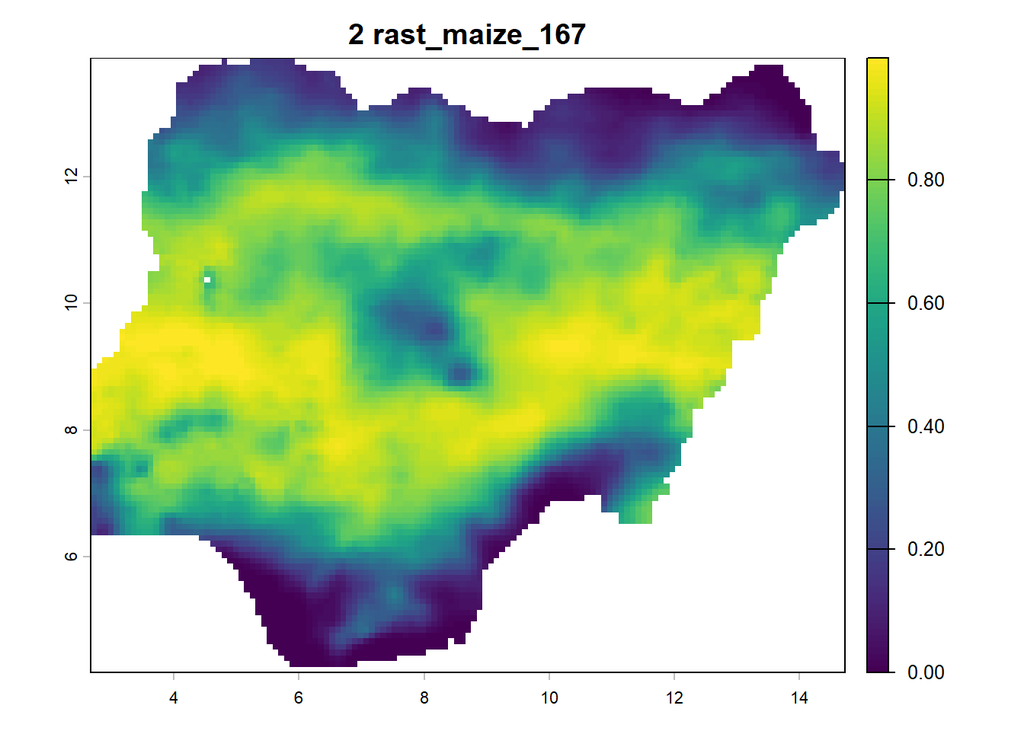

```r
rast_maize_167 <- rast("E:/repos/IRM_shiny/results/maize_generic_nigeria_167_cassava_generic_nigeria_2030_10000_NG/spatial_data/optsubopt_Precipitation Aptitude_maize_generic_nigeria_167_10000_NG.tif") |> project(wkt_geo)

plot(rast_maize_167$optimal, main = "2 rast_maize_167")
```

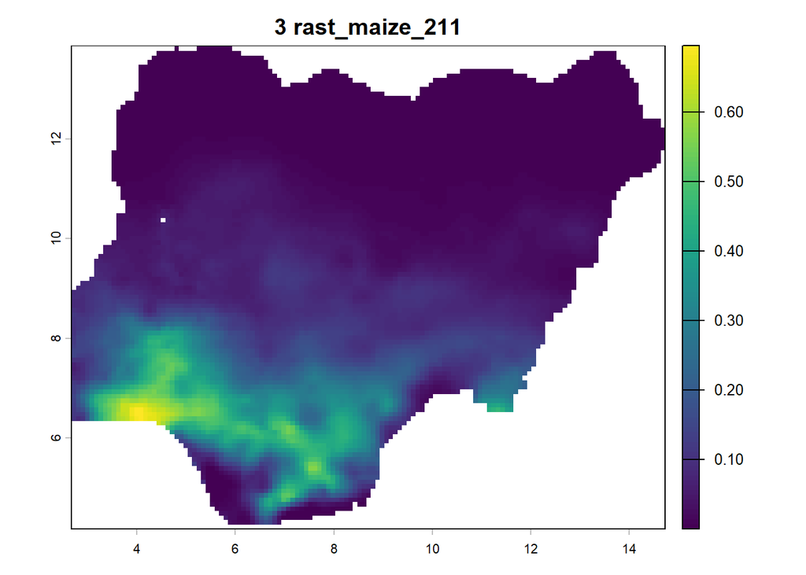

```r
rast_maize_211 <- rast("E:/repos/IRM_shiny/results/maize_generic_nigeria_211_cassava_generic_nigeria_2030_10000_NG/spatial_data/optsubopt_Precipitation Aptitude_maize_generic_nigeria_211_10000_NG.tif") |> project(wkt_geo)

plot(rast_maize_211$optimal, main = "3 rast_maize_211")
```

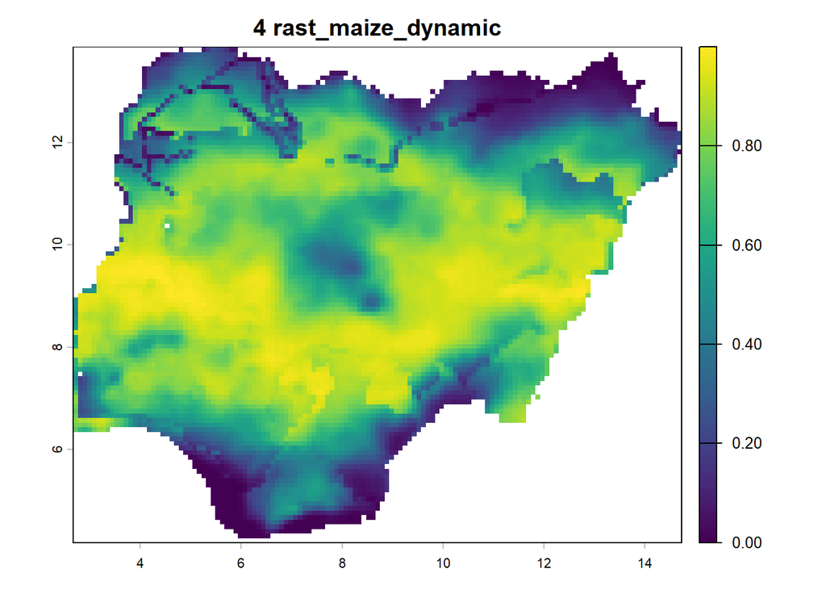

```r
rast_maize_dynamic <- rast("E:/repos/IRM_shiny/results/maize_generic_nigeria_cassava_generic_nigeria_2030_10000_NG/spatial_data/optsubopt_Precipitation Aptitude_maize_generic_nigeria_10000_NG.tif") |> project(wkt_geo)

plot(rast_maize_dynamic$optimal, main = "4 rast_maize_dynamic")
```

```r
rast_pptopt_layers <- c(
  rast_maize_140[["optimal"]],
  rast_maize_167[["optimal"]],
  rast_maize_211[["optimal"]],
  rast_maize_dynamic[["optimal"]]
)

names(rast_pptopt_layers) <- c("1_140", "2_167","3_211","4_dyn")


rast_maize_pptopt_max <- max(rast_pptopt_layers, na.rm = TRUE) |> resample(rast_maize)
rast_maize_pptopt_max
```

```
class       : SpatRaster
size        : 116, 144, 1  (nrow, ncol, nlyr)
resolution  : 0.08333333, 0.08333334  (x, y)
extent      : 2.666674, 14.66667, 4.25, 13.91667  (xmin, xmax, ymin, ymax)
coord. ref. : lon/lat WGS 84 (with axis order normalized for visualization)
source(s)   : memory
name        :      max
min value   : 0.000165
max value   : 0.999089
```

```r
rast_maize_pptopt_whichmax <- which.max(rast_pptopt_layers) |> resample(rast_maize, method="modal")
rast_maize_pptopt_whichmax
```

```
class       : SpatRaster
size        : 116, 144, 1  (nrow, ncol, nlyr)
resolution  : 0.08333333, 0.08333334  (x, y)
extent      : 2.666674, 14.66667, 4.25, 13.91667  (xmin, xmax, ymin, ymax)
coord. ref. : lon/lat WGS 84 (with axis order normalized for visualization)
source(s)   : memory
name        : which.max
min value   :         1
max value   :         4
```

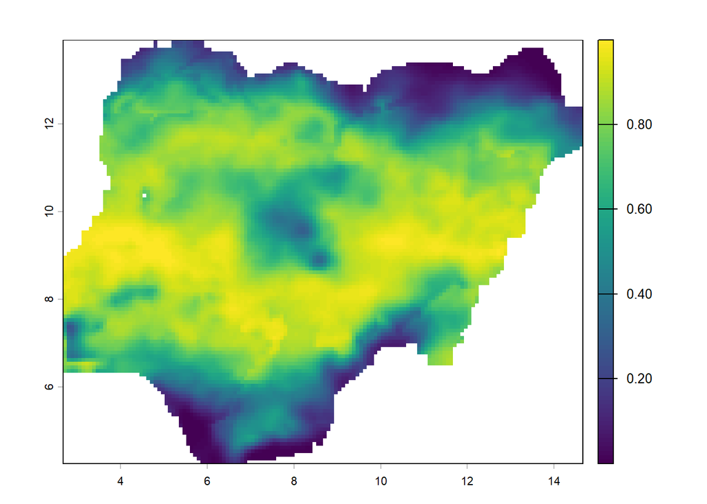

```r
plot(rast_maize_pptopt_max)
```

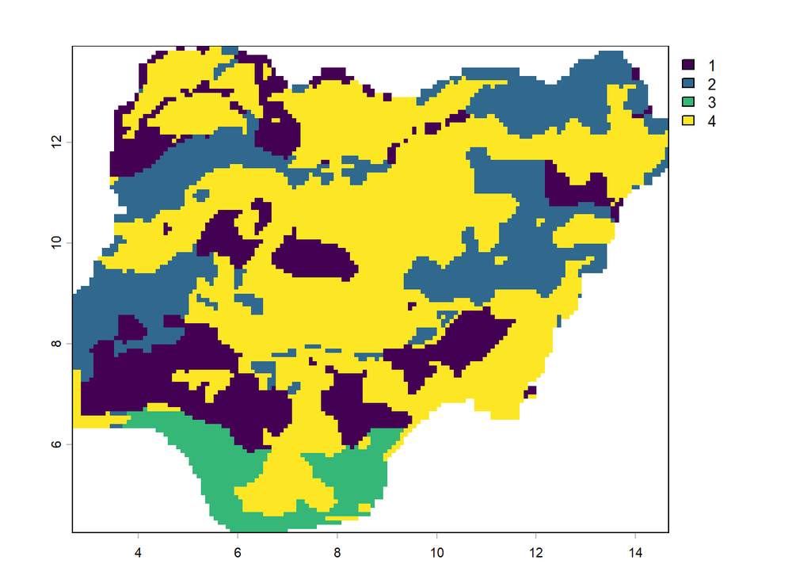

```r
plot(rast_maize_pptopt_whichmax)
```

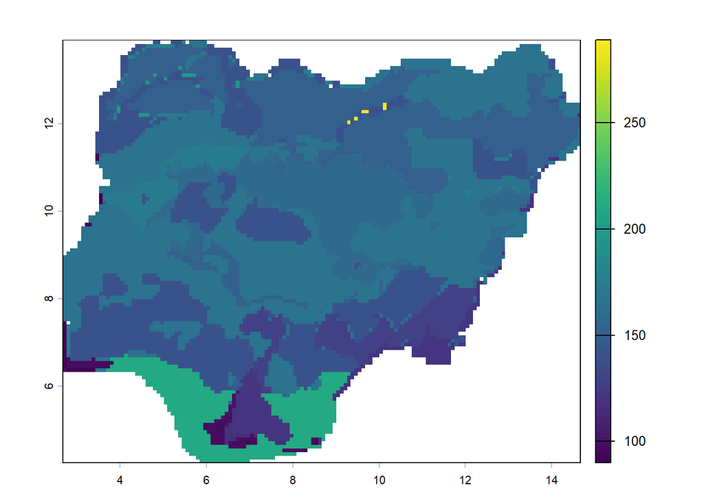

```r
rast_maize_revised <- ifel(
    rast_maize_pptopt_whichmax == 1,
    140,
    ifel(
      rast_maize_pptopt_whichmax == 2,
      167,
      ifel(rast_maize_pptopt_whichmax == 3, 211, rast_maize )
    )
  )

plot(rast_maize_revised)
```

```r
# writeRaster(rast_maize_revised, "E:/repos/IRM_shiny/data/spatial_data/onset_maize_generic_nigeria_dyn.tif", overwrite=TRUE)
```

## Rice

FEWSNET > CCD

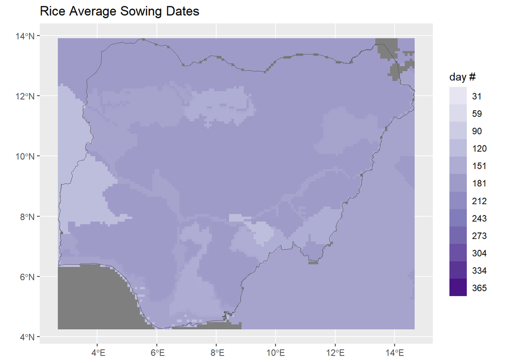

```r
rast_rice_lz_rsmp <- resample(rast_rice_lz, rast_rice_ccd )
rast_rice_sacra <- resample(rast_sow1_sacra, rast_rice_ccd )

rast_rice <- ifel(
  !is.na(rast_rice_lz_rsmp),  rast_rice_lz_rsmp, rast_rice_ccd$plant)


ggplot() +
  geom_spatraster(data = rast_rice) +
    scale_fill_distiller(
    type = "seq",
    palette = "Purples",
    direction = 1,
    limits = c(1, 365),
    breaks = c(31,59,90,120,151,181,212,243,273,304,334,365),
    labels = label_comma(),
    guide = "legend"
  ) +
  geom_spatvector(data = vect_ng_geo, fill = NA) +
  labs(title = "Rice Average Sowing Dates", fill = "day #") +
  theme(
    plot.title = element_markdown(),
    axis.title = element_blank()
  )
```

```r
# writeRaster(rast_rice, "E:/repos/IRM_shiny/data/spatial_data/onset_rice_generic_nigeria.tif", overwrite=TRUE)
```

The sowing dates above gave good results for most areas. But the pattern in the north of Nigeria, looks odd.

Therefore, we tried a number of static sowing dates to test their impact on climatic suitability.

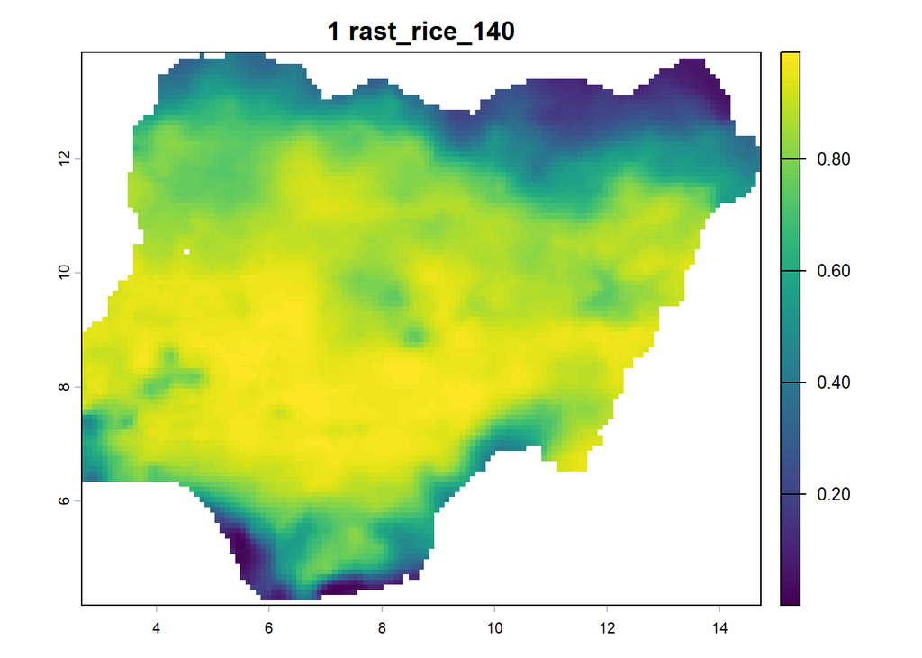

```r
wkt_geo <-  paste0( "
  GEOGCRS[\"WGS 84 (with axis order normalized for visualization)\",
          ENSEMBLE[\"World Geodetic System 1984 ensemble\",
                   MEMBER[\"World Geodetic System 1984 (Transit)\",
                          ID[\"EPSG\",1166]],
                   MEMBER[\"World Geodetic System 1984 (G730)\",
                          ID[\"EPSG\",1152]],
                   MEMBER[\"World Geodetic System 1984 (G873)\",
                          ID[\"EPSG\",1153]],
                   MEMBER[\"World Geodetic System 1984 (G1150)\",
                          ID[\"EPSG\",1154]],
                   MEMBER[\"World Geodetic System 1984 (G1674)\",
                          ID[\"EPSG\",1155]],
                   MEMBER[\"World Geodetic System 1984 (G1762)\",
                          ID[\"EPSG\",1156]],
                   MEMBER[\"World Geodetic System 1984 (G2139)\",
                          ID[\"EPSG\",1309]],
                   ELLIPSOID[\"WGS 84\",6378137,298.257223563,
                             LENGTHUNIT[\"metre\",1],
                             ID[\"EPSG\",7030]],
                   ENSEMBLEACCURACY[2.0],
                   ID[\"EPSG\",6326]],
          PRIMEM[\"Greenwich\",0,
                 ANGLEUNIT[\"degree\",0.0174532925199433],
                 ID[\"EPSG\",8901]],
          CS[ellipsoidal,2],
          AXIS[\"geodetic longitude (Lon)\",east,
               ORDER[1],
               ANGLEUNIT[\"degree\",0.0174532925199433,
                         ID[\"EPSG\",9122]]],
          AXIS[\"geodetic latitude (Lat)\",north,
               ORDER[2],
               ANGLEUNIT[\"degree\",0.0174532925199433,
                         ID[\"EPSG\",9122]]],
          USAGE[
            SCOPE[\"Horizontal component of 3D system.\"],
            AREA[\"World.\"],
            BBOX[-90,-180,90,180]],
          REMARK[\"Axis order reversed compared to EPSG:4326\"]]")


rast_rice_140 <- rast("E:/repos/IRM_shiny/results//rice_generic_nigeria_140_rice_generic_nigeria_2030_10000_NG/spatial_data/optsubopt_Precipitation Aptitude_rice_generic_nigeria_140_10000_NG.tif") |> project(wkt_geo)

plot(rast_rice_140$optimal, main = "1 rast_rice_140")
```

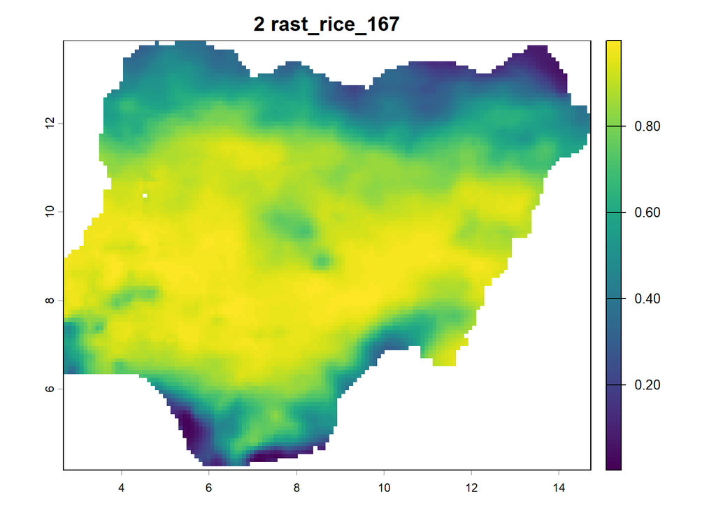

```r
rast_rice_167 <- rast("E:/repos/IRM_shiny/results//rice_generic_nigeria_167_rice_generic_nigeria_2030_10000_NG/spatial_data/optsubopt_Precipitation Aptitude_rice_generic_nigeria_167_10000_NG.tif") |> project(wkt_geo)

plot(rast_rice_167$optimal, main = "2 rast_rice_167")
```

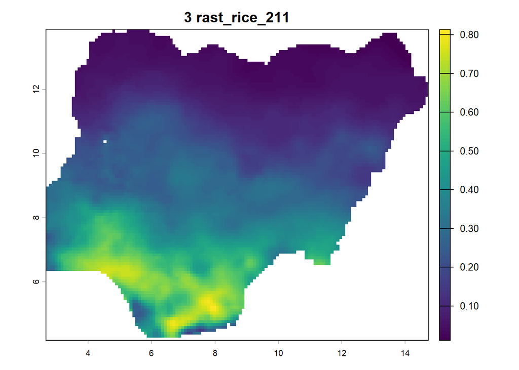

```r
rast_rice_211 <- rast("E:/repos/IRM_shiny/results/rice_generic_nigeria_211_rice_generic_nigeria_2030_10000_NG/spatial_data/optsubopt_Precipitation Aptitude_rice_generic_nigeria_211_10000_NG.tif") |> project(wkt_geo)

plot(rast_rice_211$optimal, main = "3 rast_rice_211")
```

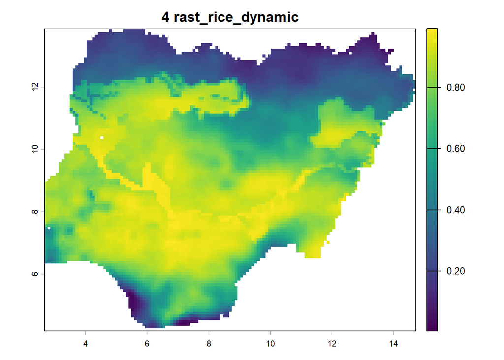

```r
rast_rice_dynamic <- rast("E:/repos/IRM_shiny/results/rice_generic_nigeria_rice_generic_nigeria_2030_10000_NG/spatial_data/optsubopt_Precipitation Aptitude_rice_generic_nigeria_10000_NG.tif") |> project(wkt_geo)

plot(rast_rice_dynamic$optimal, main = "4 rast_rice_dynamic")
```

```r
rast_pptopt_layers <- c(
  rast_rice_140[["optimal"]],
  rast_rice_167[["optimal"]],
  rast_rice_211[["optimal"]],
  rast_rice_dynamic[["optimal"]]
)

names(rast_pptopt_layers) <- c("1_140", "2_167","3_211","4_dyn")


rast_rice_pptopt_max <- max(rast_pptopt_layers, na.rm = TRUE) |> resample(rast_rice)
rast_rice_pptopt_max
```

```
class       : SpatRaster
size        : 116, 144, 1  (nrow, ncol, nlyr)
resolution  : 0.08333333, 0.08333334  (x, y)
extent      : 2.666674, 14.66667, 4.25, 13.91667  (xmin, xmax, ymin, ymax)
coord. ref. : lon/lat WGS 84 (with axis order normalized for visualization)
source(s)   : memory
name        :      max
min value   : 0.059235
max value   : 0.996679
```

```r
rast_rice_pptopt_whichmax <- which.max(rast_pptopt_layers) |> resample(rast_rice, method="modal")
rast_rice_pptopt_whichmax
```

```
class       : SpatRaster
size        : 116, 144, 1  (nrow, ncol, nlyr)
resolution  : 0.08333333, 0.08333334  (x, y)
extent      : 2.666674, 14.66667, 4.25, 13.91667  (xmin, xmax, ymin, ymax)
coord. ref. : lon/lat WGS 84 (with axis order normalized for visualization)
source(s)   : memory
name        : which.max
min value   :         1
max value   :         4
```

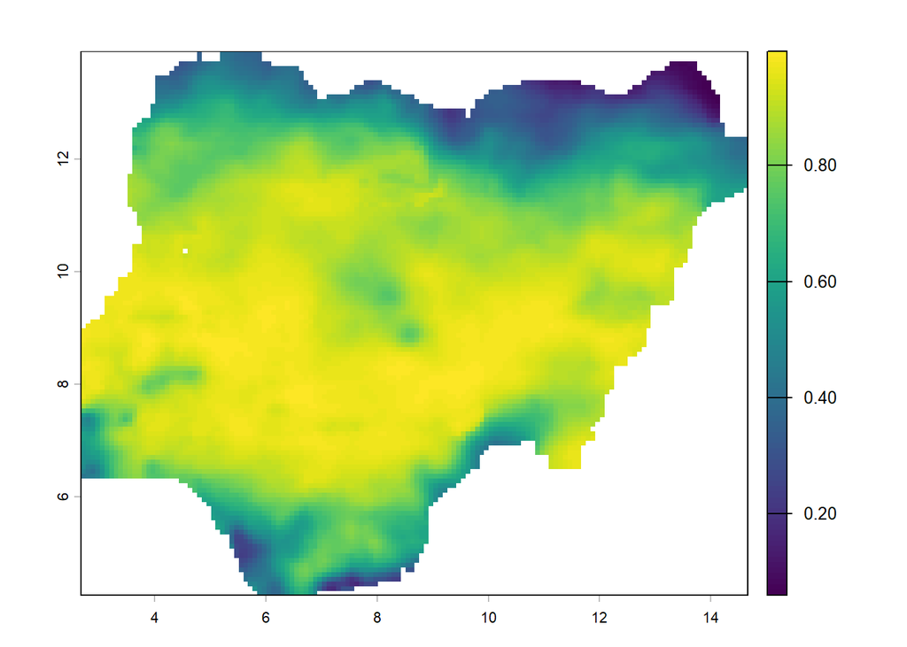

```r
plot(rast_rice_pptopt_max)
```

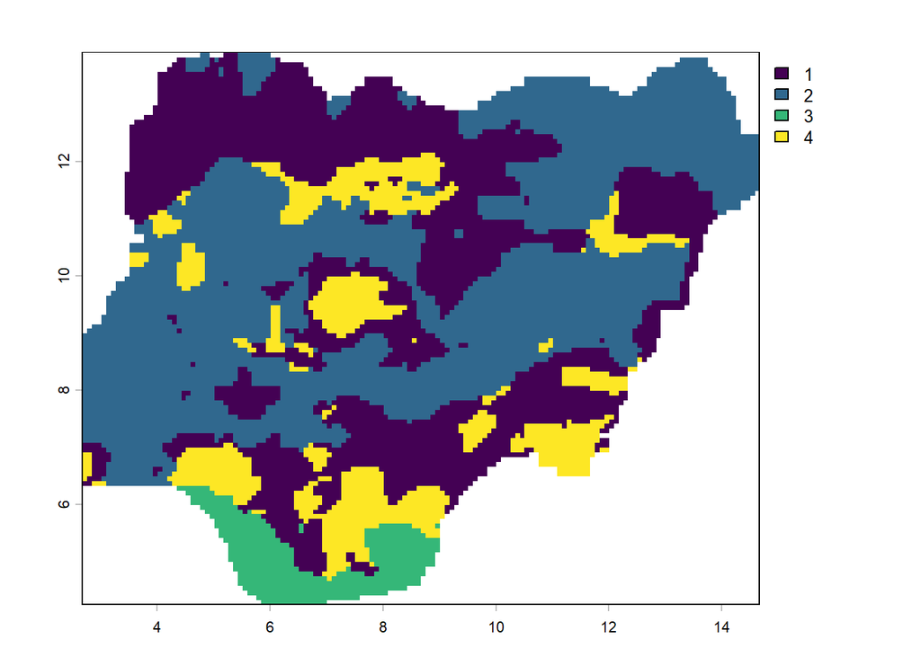

```r
plot(rast_rice_pptopt_whichmax)
```

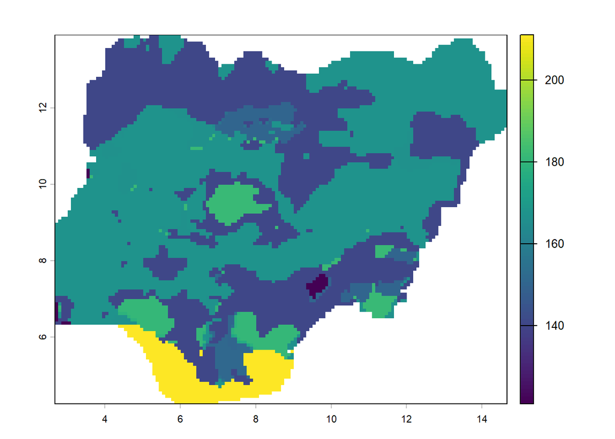

```r
rast_rice_revised <- ifel(
    rast_rice_pptopt_whichmax == 1,
    140,
    ifel(
      rast_rice_pptopt_whichmax == 2,
      167,
      ifel(rast_rice_pptopt_whichmax == 3, 211, rast_rice )
    )
  )

plot(rast_rice_revised)
```

```r
# writeRaster(rast_rice_revised, "E:/repos/IRM_shiny/data/spatial_data/onset_rice_generic_nigeria_dyn.tif", overwrite=TRUE)
```

## Sweet Potato

FEWSNET > CCD

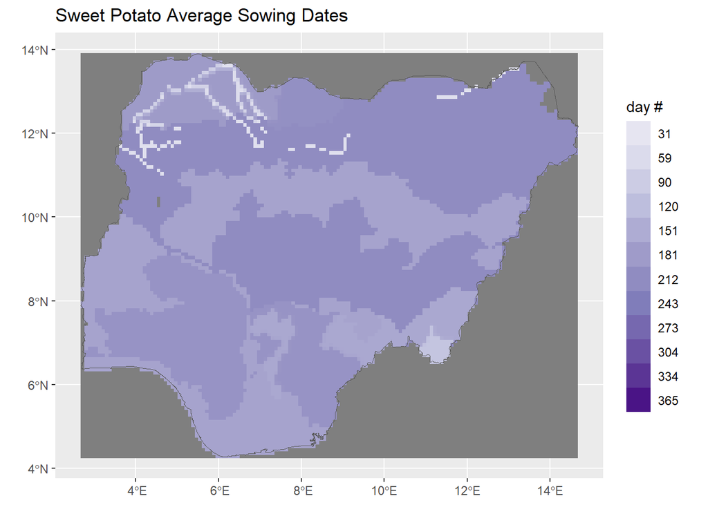

```r
rast_spot_lz_rsmp <- resample(rast_spot_lz, rast_spot_ccd )
rast_spot_sacra <- resample(rast_sow1_sacra, rast_spot_ccd )

rast_spot <- ifel(
  !is.na(rast_spot_lz_rsmp),  rast_spot_lz_rsmp, rast_spot_ccd$plant)


ggplot() +
  geom_spatraster(data = rast_spot) +
    scale_fill_distiller(
    type = "seq",
    palette = "Purples",
    direction = 1,
    limits = c(1, 365),
    breaks = c(31,59,90,120,151,181,212,243,273,304,334,365),
    labels = label_comma(),
    guide = "legend"
  ) +
  geom_spatvector(data = vect_ng_geo, fill = NA) +
  labs(title = "Sweet Potato Average Sowing Dates", fill = "day #") +
  theme(
    plot.title = element_markdown(),
    axis.title = element_blank()
  )
```

```r
# writeRaster(rast_spot, "E:/repos/IRM_shiny/data/spatial_data/onset_spot_generic_nigeria.tif", overwrite=TRUE)
```

The sowing dates above gave good results for most areas. But the pattern in the north of Nigeria is patchy.

Therefore, we tried a number of static sowing dates to test their impact on climatic suitability.

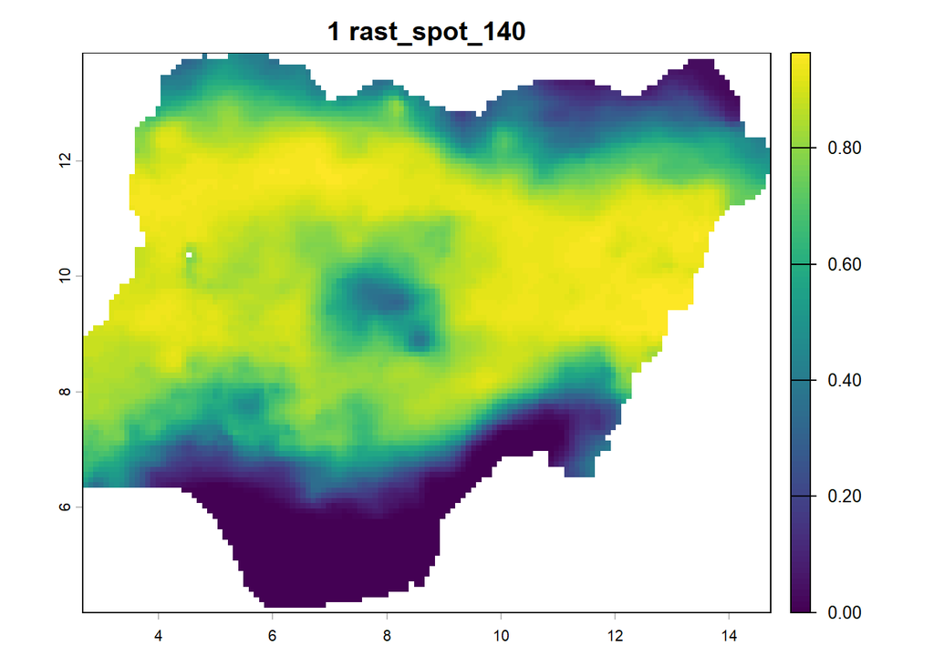

```r
wkt_geo <-  paste0( "
  GEOGCRS[\"WGS 84 (with axis order normalized for visualization)\",
          ENSEMBLE[\"World Geodetic System 1984 ensemble\",
                   MEMBER[\"World Geodetic System 1984 (Transit)\",
                          ID[\"EPSG\",1166]],
                   MEMBER[\"World Geodetic System 1984 (G730)\",
                          ID[\"EPSG\",1152]],
                   MEMBER[\"World Geodetic System 1984 (G873)\",
                          ID[\"EPSG\",1153]],
                   MEMBER[\"World Geodetic System 1984 (G1150)\",
                          ID[\"EPSG\",1154]],
                   MEMBER[\"World Geodetic System 1984 (G1674)\",
                          ID[\"EPSG\",1155]],
                   MEMBER[\"World Geodetic System 1984 (G1762)\",
                          ID[\"EPSG\",1156]],
                   MEMBER[\"World Geodetic System 1984 (G2139)\",
                          ID[\"EPSG\",1309]],
                   ELLIPSOID[\"WGS 84\",6378137,298.257223563,
                             LENGTHUNIT[\"metre\",1],
                             ID[\"EPSG\",7030]],
                   ENSEMBLEACCURACY[2.0],
                   ID[\"EPSG\",6326]],
          PRIMEM[\"Greenwich\",0,
                 ANGLEUNIT[\"degree\",0.0174532925199433],
                 ID[\"EPSG\",8901]],
          CS[ellipsoidal,2],
          AXIS[\"geodetic longitude (Lon)\",east,
               ORDER[1],
               ANGLEUNIT[\"degree\",0.0174532925199433,
                         ID[\"EPSG\",9122]]],
          AXIS[\"geodetic latitude (Lat)\",north,
               ORDER[2],
               ANGLEUNIT[\"degree\",0.0174532925199433,
                         ID[\"EPSG\",9122]]],
          USAGE[
            SCOPE[\"Horizontal component of 3D system.\"],
            AREA[\"World.\"],
            BBOX[-90,-180,90,180]],
          REMARK[\"Axis order reversed compared to EPSG:4326\"]]")


rast_spot_140 <- rast("E:/repos/IRM_shiny/results/spot_generic_nigeria_140_rice_generic_nigeria_2030_10000_NG/spatial_data/optsubopt_Precipitation Aptitude_spot_generic_nigeria_140_10000_NG.tif") |> project(wkt_geo)

plot(rast_spot_140$optimal, main = "1 rast_spot_140")
```

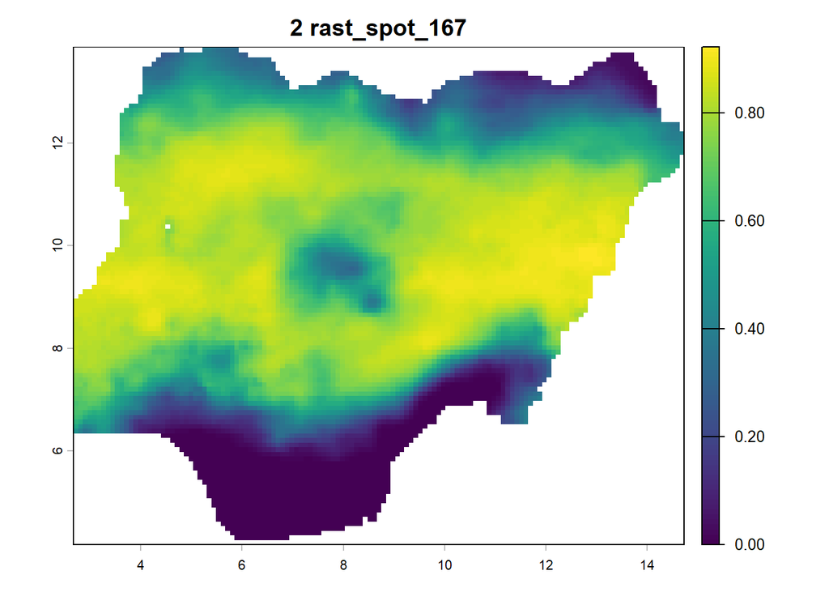

```r
rast_spot_167 <- rast("E:/repos/IRM_shiny/results/spot_generic_nigeria_167_rice_generic_nigeria_2030_10000_NG/spatial_data/optsubopt_Precipitation Aptitude_spot_generic_nigeria_167_10000_NG.tif") |> project(wkt_geo)

plot(rast_spot_167$optimal, main = "2 rast_spot_167")
```

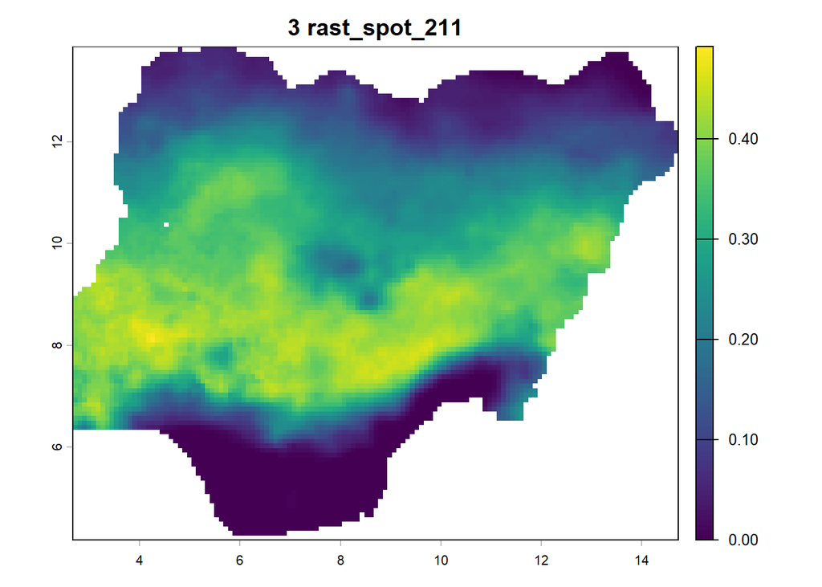

```r
rast_spot_211 <- rast("E:/repos/IRM_shiny/results/spot_generic_nigeria_211_rice_generic_nigeria_2030_10000_NG/spatial_data/optsubopt_Precipitation Aptitude_spot_generic_nigeria_211_10000_NG.tif") |> project(wkt_geo)

plot(rast_spot_211$optimal, main = "3 rast_spot_211")
```

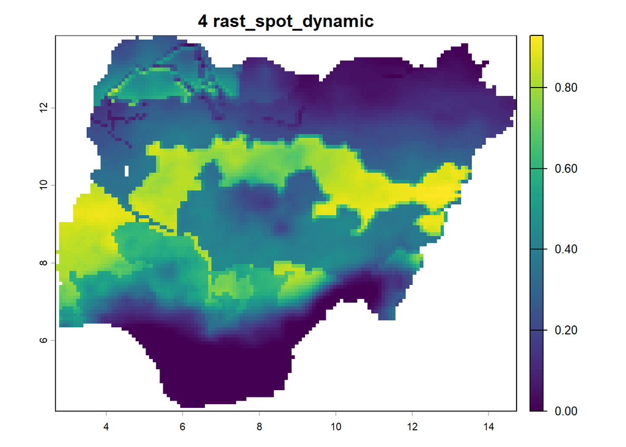

```r
rast_spot_dynamic <- rast("E:/repos/IRM_shiny/results/spot_generic_nigeria_rice_generic_nigeria_2030_10000_NG/spatial_data/optsubopt_Precipitation Aptitude_spot_generic_nigeria_10000_NG.tif") |> project(wkt_geo)

plot(rast_spot_dynamic$optimal, main = "4 rast_spot_dynamic")
```

```r
rast_pptopt_layers <- c(
  rast_spot_140[["optimal"]],
  rast_spot_167[["optimal"]],
  rast_spot_211[["optimal"]],
  rast_spot_dynamic[["optimal"]]
)

names(rast_pptopt_layers) <- c("1_140", "2_167","3_211","4_dyn")


rast_spot_pptopt_max <- max(rast_pptopt_layers, na.rm = TRUE) |> resample(rast_spot)
rast_spot_pptopt_max
```

```
class       : SpatRaster
size        : 116, 144, 1  (nrow, ncol, nlyr)
resolution  : 0.08333333, 0.08333334  (x, y)
extent      : 2.666674, 14.66667, 4.25, 13.91667  (xmin, xmax, ymin, ymax)
coord. ref. : lon/lat WGS 84 (with axis order normalized for visualization)
source(s)   : memory
name        :      max
min value   :        0
max value   : 0.963163
```

```r
rast_spot_pptopt_whichmax <- which.max(rast_pptopt_layers) |> resample(rast_spot, method="modal")
rast_spot_pptopt_whichmax
```

```
class       : SpatRaster
size        : 116, 144, 1  (nrow, ncol, nlyr)
resolution  : 0.08333333, 0.08333334  (x, y)
extent      : 2.666674, 14.66667, 4.25, 13.91667  (xmin, xmax, ymin, ymax)
coord. ref. : lon/lat WGS 84 (with axis order normalized for visualization)
source(s)   : memory
name        : which.max
min value   :         1
max value   :         4
```

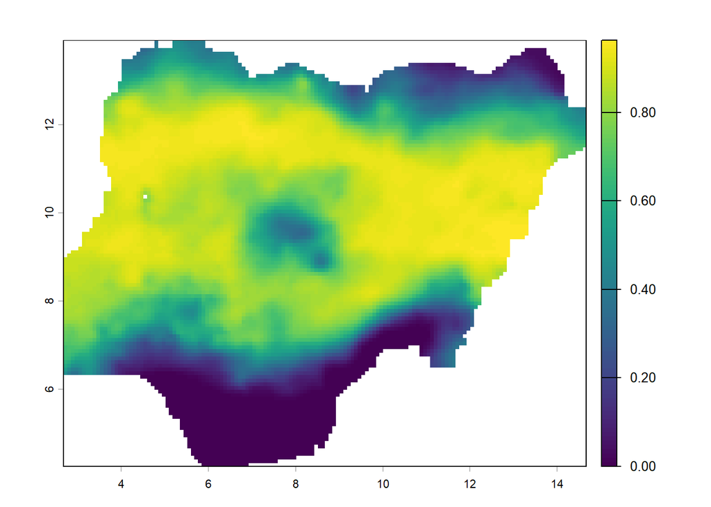

```r
plot(rast_spot_pptopt_max)
```

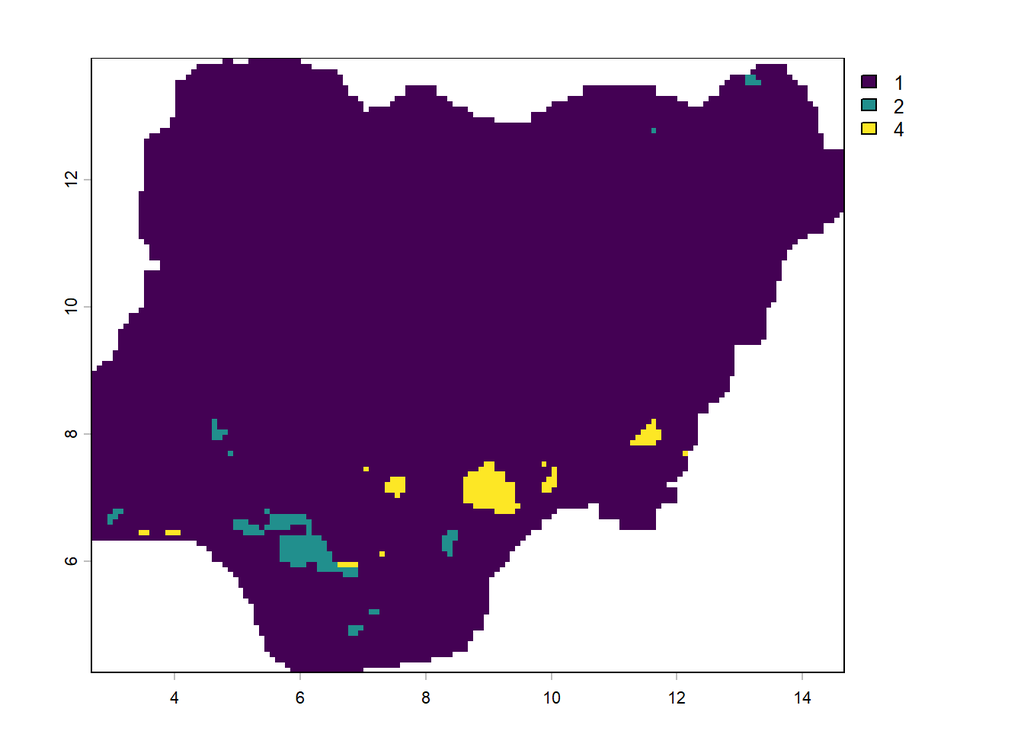

```r
plot(rast_spot_pptopt_whichmax)
```

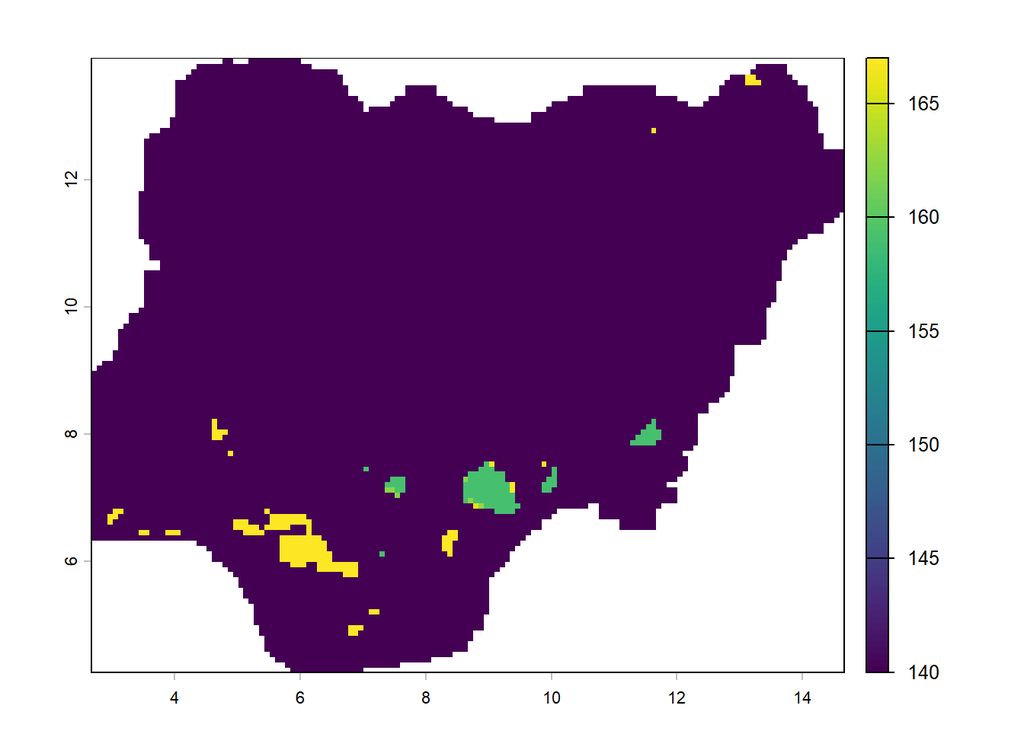

```r
rast_spot_revised <- ifel(
    rast_spot_pptopt_whichmax == 1,
    140,
    ifel(
      rast_spot_pptopt_whichmax == 2,
      167,
      ifel(rast_spot_pptopt_whichmax == 3, 211, rast_spot )
    )
  )

plot(rast_spot_revised)
```

```r
# writeRaster(rast_spot_revised, "E:/repos/IRM_shiny/data/spatial_data/onset_spot_generic_nigeria_dyn.tif", overwrite=TRUE)
```